# MEDB 5502, Module09, Meta-analysis

## Topics to be covered

- What you will learn
  - What is meta-analysis
  - Heterogeneity
  - Study quality
  - Publication bias
  - Interpretability of results
  - Numeric summaries
  - Strengths and weaknesses

## Meta-analysis

- Quantitative pooling of results from multiple studies
  - Multi-center study
    - Each center has a different protocol
    - Some centers do not share results
- Contrast to systematic overview
  - Careful review of multiple studies
  - May or may not include quantitative pooling
- Contrast to scoping review
  - “Researchers may conduct scoping reviews instead of systematic reviews where the purpose of the review is to identify knowledge gaps, scope a body of literature, clarify concepts or to investigate research conduct.” [Munn 2018](https://bmcmedresmethodol.biomedcentral.com/articles/10.1186/s12874-018-0611-x)

## Case study: Declining sperm counts

- Meta-analysis published in 1992 in BMJ
  - 62 studies
  - 1938 through 1991
  - 12 million/ml decline per decade
- Criticism
  - Early studies in North America, later studies more global
  - Variations in collection methods, abstinence requirements
  - Many competing analyses
- Bad news/good news

## Major issues in meta-analysis

- Heterogeneity
  - Were apples combined with oranges?
- Publication bias
  - Were some apples left on the tree?
- Study quality
  - Were all the apples rotten?
- Interpretability
  - Did the pile of apples amount to more than just a hill of beans?

## Break #1

- What you have learned
  - What is meta-analysis
- What’s coming next
  - Heterogeneity

## Too much heterogeneity is bad

- Mixing apples and oranges
- Example: statins
  - Primary versus secondary prevention

## Heterogeneity in patient populations

- Demographics of patients
- Exclusion critieria
- Baseline health

## Heterogeneity in sampling

- Independent versus matched samples
- Type of control
- Type of treatment

## Heterogeneity in study design

- Length of follow-up
- Drop-out rates

## Heterogeneity in patient management

- Treatment of comorbid conditions
- Handling of complications
- Physician discretion

## Heterogenity in outcome measures

- Example: hypertension treatment
  - cardiovascular deaths
  - cardiovascular events
  - cerebrovascular deaths
  - cerebrovascular events
  - deaths due to any cause

## Examples of heterogeneity

- Antiretroviral combination therapy
  - Effective in shorter trials
  - Ineffective in longer trials
- Dust mite control measures
  - Chemical or physical interventions
  - Crossover or parallel design
  - Variation in blinding
  - Age of patients
  - Duration of trial

## How to handle heterogeneity

- Some heterogenity is actually encouraged
- Subgroup analysis
- Meta-regression

## Inclusion of very old studies

- Varies by discipline
- Look for “game changing” events
  - Surfactants in neonatology
  - Anti-retrovirals for HIV patients
  - Fluouridation of water supplies

## Test of heterogeneity

- Cochran’s Q
  - Null hypothesis: homogeneity
  - Reject if chi-square statistic much larger than degrees of freedom
- I-squared
  - Descriptive measure
  - Always between 0% and 100%
  - Below 25% implies homogeneity

## Break #2

- What you have learned
  - Heterogeneity
- What’s coming next
  - Study quality

## Were all of the apples rotten?

- “You can’t make a silk purse out of a sow’s ear”
- Meta-analysis will amplify study flaws
- General (but not universal) trend
  - Lower quality leads to over-optimism

## Observational studies in a meta-analysis

- Originally very controversial
  - An exercise in “mega-silliness”
- Analyze selective subgroups
  - Insights into size and direction of biases

## Meta-analyses of randomized trials

- Often a primary inclusion factor
- Other quality concerns
  - Lack of blinding
  - High dropout rates

## Incomplete report of quality issues

- Fairly common
- Assumption: guilty until proven innocent
  - But possibly just an oversight?

## Meta-analysis of studies with small sample sizes

- Be very cautious
  - Publication bias is a much bigger threat

## Intentional exclusion of studies

- Where to draw the line?
- Example: mammography for 40-50 year old women
  - Seven studies: positive result
  - Two best studies only: negative result

## Break #3

- What you have learned
  - Study quality
- What’s coming next
  - Publication bias

## Were some apples left on the tree?

- Publication bias
  - Some research studies never get published
  - These studies more likely to be negative
- Registration of clinical trials has helped

## Duplicate publication

- Some studies pubished twice
- Multiple publications more likely to be positive - Bias from double counting
- Hard to track duplicate publications

## The limitations of a Pubmed search

- Pubmed only covers 3,000 of the 13,000 medical journals
  - Studies not in Pubmed tend to be negative

## Foreign language publications

- Convenient to restrict to English publications
- Native language publications more likely to be negative

## Picking the low hanging fruit

- Articles with full free text
- Articles with abstracts

## How to avoid bias from exclusion of publications

- Multiple bibliographic databases
- Registries
- Examination of bibliographies
- Call for “gray literature”

## Subjectivity in article selection

- Blinding
  - No author list
  - No university affiliation
  - Methods section only
- Duplicate extraction of information
  - Look for 90% or better agreement
- Detailed protocol

## Detecting and correcting for publication bias

- Compare to the unpublished studies you did find
- Stratify by sample sizes
- Funnel plot

## Break #4

- What you have learned
  - Publication bias
- What’s coming next
  - Interpretability of results

## Did the pile of apples amount to more than just a hill of beans?

- A significant meta-analysis is not enough
- Effect sizes difficult to interpret

## Vote counting

- Categorize individual studies
  - Are some/most positive?
- Negative, but trending studies

## Unitless measures

- Convert back to original units
- Example smoking cessation efforts during pregnancy
  - Statistically significant
  - Only a 28 gram difference in birthweight

## Break #5

- What you have learned
  - Interpretability of results
- What’s coming next
  - Numeric summaries

## Summary statistics for continuous outcomes

- Standardized mean difference (SMD)
  - $\frac{\bar X_2-\bar X_1}{Estimated\ standard\ deviation}$
  - Be consistent with direction
- Choices for estimated standard deviation
  - Pooled standard deviation (Cohen’s d)
  - Bias adjustment (Hedges’ g)
  - Heteroscedascity?
    - Use control variance
    - Average the two variances

## Summary statistics for categorical outcomes

- Odds ratio
  - Always on a log scale
- Relative risk
  - Always on a log scale
- Absolute difference

## Description of art-malpresentations data, 1 of 3

```
data_dictionary: art-malpresentations.csv
```

[output not shown]

[output not shown]

## Description of art-malpresentations data, 2 of 3

```
author:
  label: first author of study
study_type:
  values:
  - casecontrol
  - cohort
```

## Description of art-malpresentations data, 3 of 3

```
art_events:
  label: number of malpresentation in ART groups
art_total:
  label: number of patients in ART groups
nc_events:
  label: number of malpresentations in NC groups
nc_total:
  label: number of patients in NC groups
```

## ART results, 1 of 6

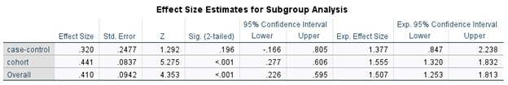

## ART results, 2 of 6

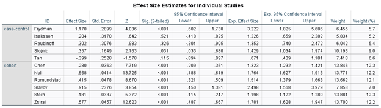

## ART results, 3 of 6

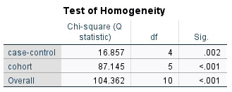

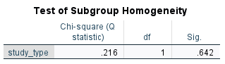

## ART results, 4 of 6

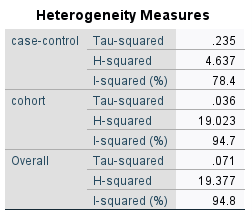

## ART results, 5 of 6

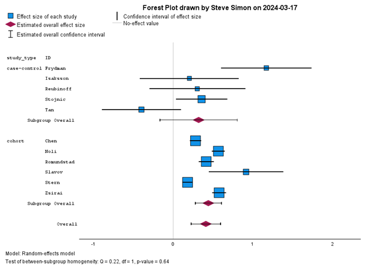

## ART results, 6 of 6

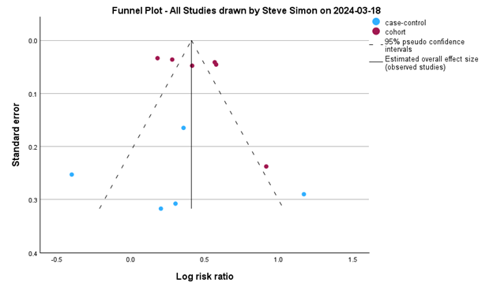

## Description of vaccine-willingness data, 1 of 3

```
data_dictionary: vaccine-willingness.yaml
```

```
description: |
  This paper identified seven studies that examined vaccine literacy (VL).  Patients in these studies also stated their  vaccine prefernce and were categorized  as willing or unwilling.
```

[output not shown]

## Description of vaccine-willingness data, 2 of 3

```
author:
  label: first author of publication
vaccine_type:
  label: Type of vaccination
  values:
  - booster
  - primary
```

## Description of vaccine-willingness data, 3 of 3

```
willing_mean:
  label: Mean VL in willing patients
willing_sd:
  label: Standard deviation of VL in willing patients
willing_n:
  label: Number of willing patients
unwilling_mean:
  label: Mean VL in unwilling patients
unwilling_sd:
  label: Standard deviation of VL in unwilling patients
unwilling_n:
  label: Number of unwilling patients
```

## Vaccine results, 1 of 6

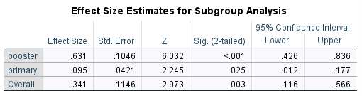

## Vaccine results, 2 of 6

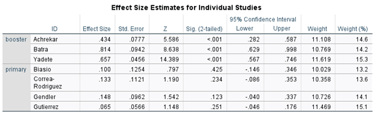

## Vaccine results, 3 of 6

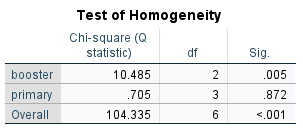

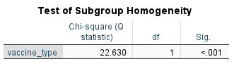

## Vaccine results, 4 of 6

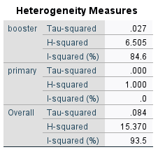

## Vaccine results, 5 of 6

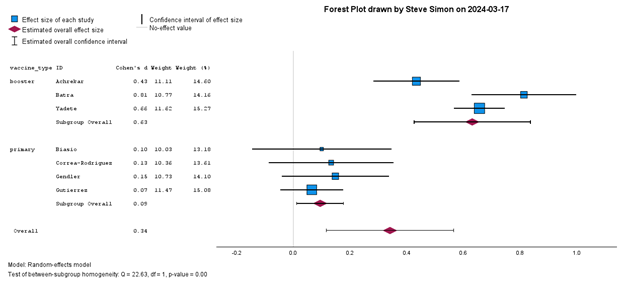

## Vaccine results, 6 of 6

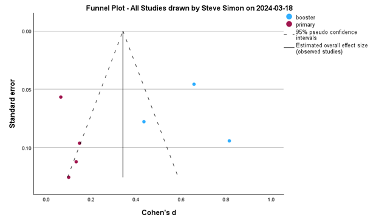

## Live demo, Numeric summaries

## Break #6

- What you have learned
  - Numeric summaries
- What’s coming next
  - Strengths and weaknesses

## Where does meta-analysis sit on the hierarchy of evidence?

- Above randomized clinical trials?
  - Heterogeneity improves generalizability
  - Avoids accusations of “cherry-picking”
- Below randomized clinical trials?
  - Too much variation in conduct of trials
  - Uncertain sampling framework

## Unstated benefits of meta-analysis

- Characterizing sources of bias
- Identifying research gaps
- Insight into when to stop researching

## Summary

- What you have learned
  - What is meta-analysis
  - Heterogeneity
  - Study quality
  - Publication bias
  - Interpretability of results
  - Numeric summaries
  - Strengths and weaknesses

## Additional references

- See speaker notes for additional references